# GoMx Risso’s dolphin habitat models: Presence/absence with neural nets

Kaitlin Frasier

Scripps Institution of Oceanography, UC San Diego

28 September 2019

# 1. Exploratory analysis

## 1.1 Data Inputs

NOAA SEFSC visual data goes back to 1992, but as shown in the figure below, many predictor variables are only available starting in 2003, therefore earlier visual data is currently excluded from further analyses.

Note: Future work could use monthly climatologies (averages) so that older sightings data could be used. Some dynamic drivers like eddy and front locations would not be able to be considered using that approach.

**Visual data predictor variable availability:**

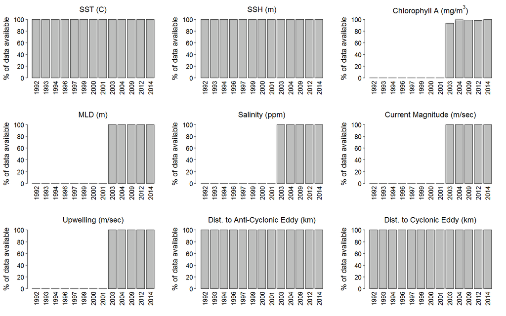

### 1.1.1 Splitting into testing and training sets

The data are split into training and testing sets. In this case, visual data from 2009 and acoustic data from 2013 were used only for testing. Only observations from 2003 or later were used for modeling due to covariate limitations.

### 1.1.2 Map of visual sightings data

The visual data selected for modeling are displayed on the map below. Data from 2009 were held back for testing. Blue markers indicate HARP locations.

[interactive chart not shown]

### 1.1.3 Time series of acoustic data

The time series below show timeseries of estimated densities from passive acoustic data used for modeling (Densities were calculated following methods detailed in [1]). Data from 2011 and 2012 were used for training, and 2013 data was held back for testing.

**Acoustic Timeseries:**

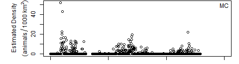

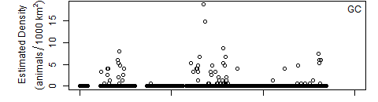

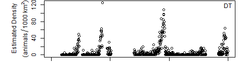

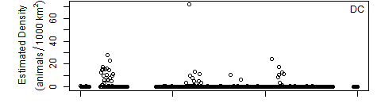

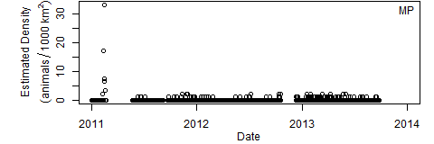

## 1.2 Examination of covariates

### 1.2.1 Covariate distribution check

**Distributions of covariates from acoustic observations (training data only):**

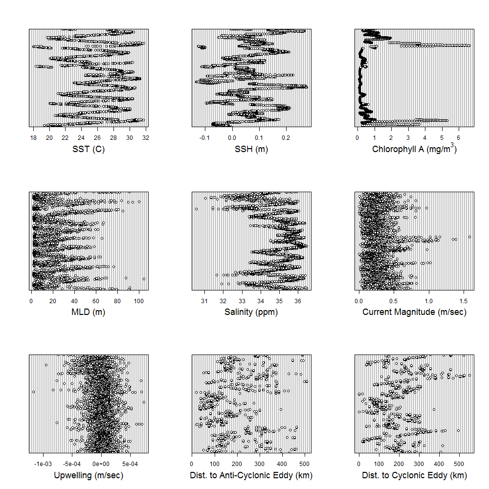

**Distributions of covariates from the visual observations (training data only):**

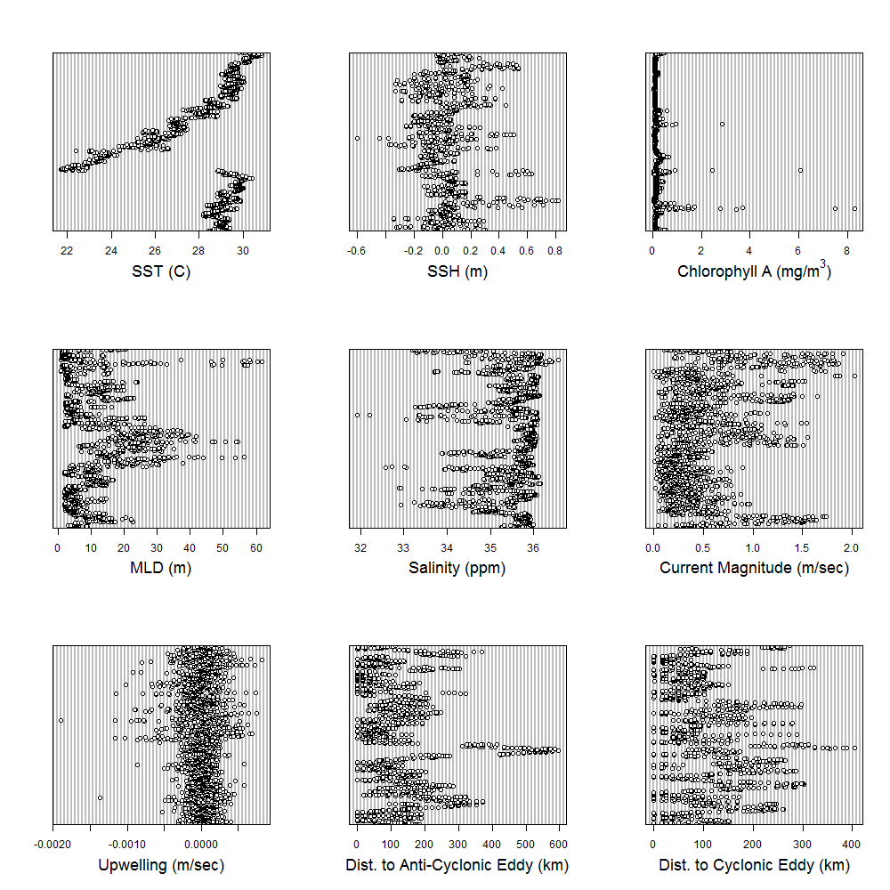

Some of these covariates are more or less interrelated. Correlations are examined in the figure below. Numbers closer to 1 above the diagonal in the figure below represent correlation coefficients. If a pair of covariates is highly-correlated only one should typically be used in the model.

**Covariate Correlations:**

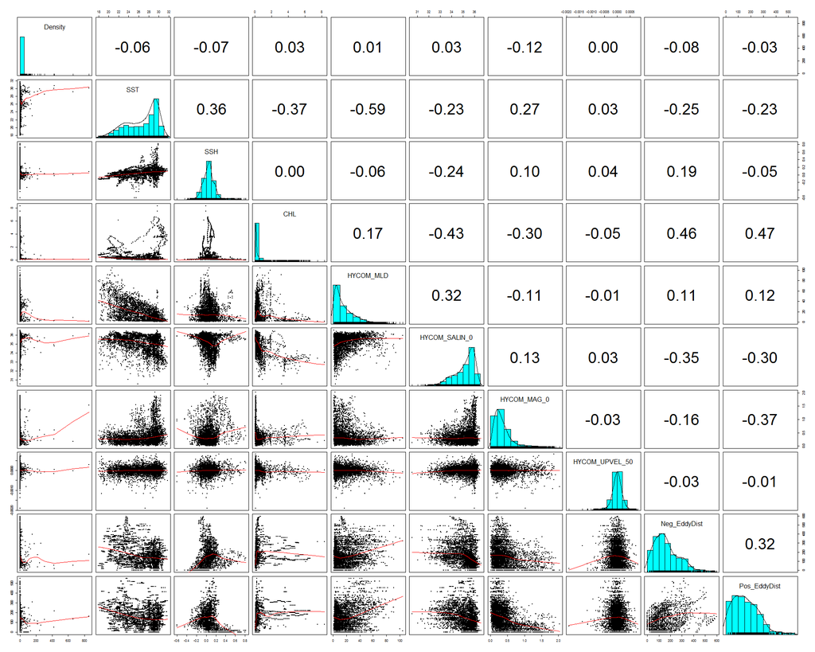

### 1.2.2 Transformation of predictor variables

Below, the two sets of covariates have been combined and transformed:

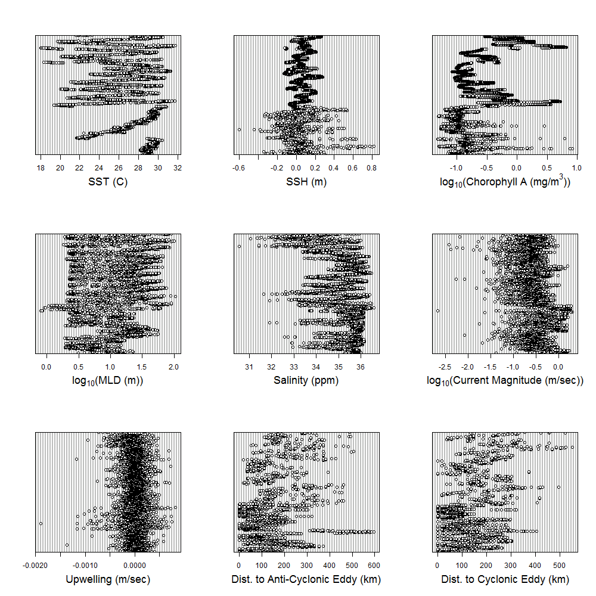

### 1.2.3 Preliminary check of predictive power

To get an idea of the basic predictive power of these covariates, we can look at presence/absence relative to each variable. This also provides an opportunity to look at the range of values observed for each covariate in the visual and acoustic datasets. In the plots below dotted lines indicate the distribution of each covariate when Risso’s dolphin were present, and solid lines indicate the distribution when Risso’s dolphin were absent. Note that these plots do not account for effort.

**Acoustic kernel densities:**

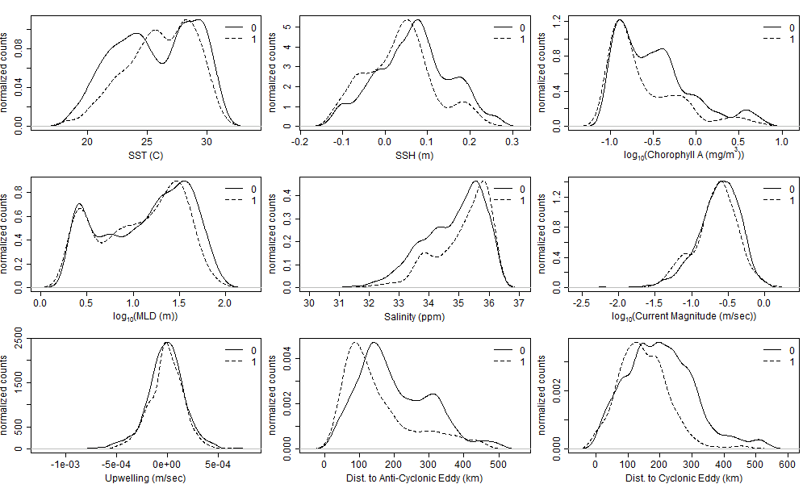

**Visual kernel densities:**

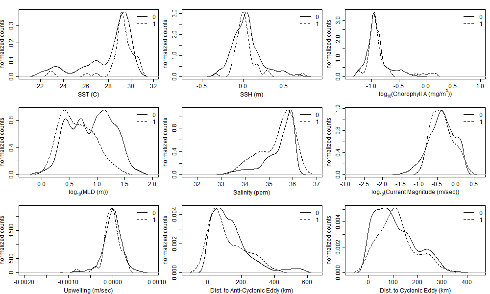

### 1.2.4 Estimation of relative weights

To train the model, we need to know how much power the various data points have relative to one another. This is important because the duration, spatial coverage, and detection probabilities are quite different between the visual and acoustic data sets. If an animal is seen or heard, we know for certain that the species was present. However, if it was not heard, then it either wasn’t present, or it was present but missed.

“Zero inflation” or an excess of false zeros more common in the visual survey data because each data point represents a 10km transect section, traversed at survey speed (>10 knots) or approximately 30 minutes of observation effort. In contrast, the acoustic data are binned by day with a stationary instrument, therefore the probability of missing a group over the course of a day is lower.

For each data type, we estimated the probability of a missed detection to account for differences in zero-inflation, downweighting zeros according to the probability of a recording false negative.

The visual data represent wether or not Risso’s dolphin were seen during each transect segment. The probability of missing a sighting of Risso’s dolphin was estimated as

$$P_{V}(detect|present) = \mu_{det} * g0\ = 0.29 * 0.8 = 0.24$$

where _{det} is the mean detection probability as estimated by a model fit using the mrds package, and g0 is the probability of observing an animal on the transect line [2]. We assume that reported absences are likely to be true absences 24 % of the time, therefore zeros are given a weight of 0.24 on a scale of [0,1].

**Best visual detection probability model for Risso’s dolphin:**

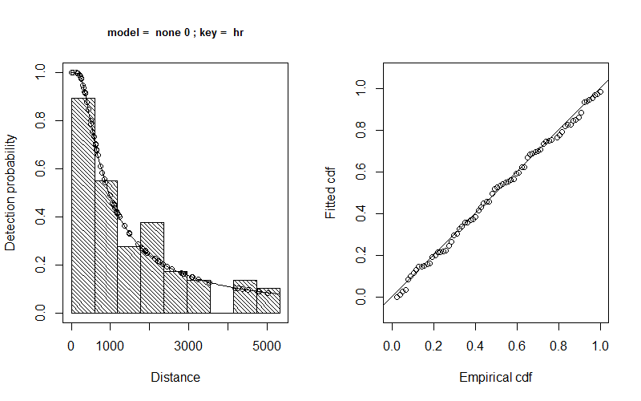

# 2. Model Fitting

Models were fit using avnnet from the caret package in R.

## 2.1 Run Models

Run NNs Acoustic only, Visual only, and joint Acoustic/Visual datasets.

## 2.2 Model Comparisons

```
## [1] "cross entropy scores (lower is better)"
```

```
##                           4     6     8    10    12    14
## Acoustic - Weighted   0.243 0.249 0.247 0.265 0.285 0.278
## Visual - Weighted     0.544 2.267 2.269 2.542 2.424 2.406
## Joint - Weighted      0.258 0.250 0.274 0.281 0.286 0.331
## Acoustic - Unweighted 5.426 5.288 5.308 5.465 5.524 5.386
## Visual - Unweighted   5.091 5.072 5.052 5.111 5.091 5.111
## Joint - Unweighted    5.131 4.875 5.013 5.052 5.013 4.934
```

```
## [1] "Best acoustic model has 4 nodes."
```

```
## [1] "Best visual model has 4 nodes."
```

```
## [1] "Best joint model has 6 nodes."
```

## 2.3 Variable Importance

For the best model in each category, the importance of each input variable was calculated across the 50 model iterations.

|  | AcOnly | VisOnly | Joint |
| --- | --- | --- | --- |
| SST | 9.7 | 13.1 | 11.4 |
| SSH | 25.5 | 12.2 | 21.8 |
| log10_CHL | 14.3 | 10.9 | 13.8 |
| log10_HYCOM_MLD | 5.4 | 12.4 | 6.2 |
| HYCOM_SALIN_0 | 18.3 | 14.3 | 14.4 |
| log10_HYCOM_MAG_0 | 3.3 | 9.3 | 5.4 |
| HYCOM_UPVEL_50 | 5.5 | 7.8 | 6.7 |
| Neg_EddyDist | 8.7 | 9.2 | 8.7 |
| Pos_EddyDist | 9.2 | 10.9 | 11.7 |

*Example network:*

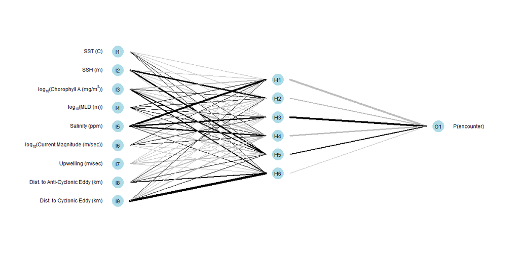

# 3. Model Predictions

## 3.1 Temporal predictions

Predictions were made on the acoustic test dataset, and compared with actual observations for 2013. The predicted probabliity of encountering animals was compared with the actual weekly rate of occurrence of animals at a site.

CAVEAT: Encounter probability from the data is estimated as fraction of days per week during which this species was detected.

### 3.1.1 Acoustic-only prediction

**Predicted and observed encounter probabilities at passive acoustic monitoring sites using the acoustic-only model:**

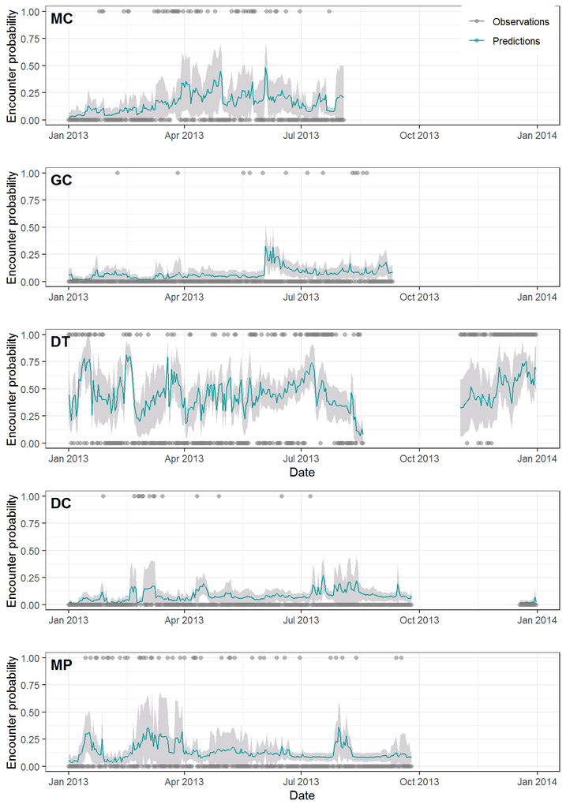

### 3.1.2 Visual-only prediction

**Predicted and observed encounter probabilities at passive acoustic sites using the visual-only model (Site order: MC, GC, DT, DC, MP):**

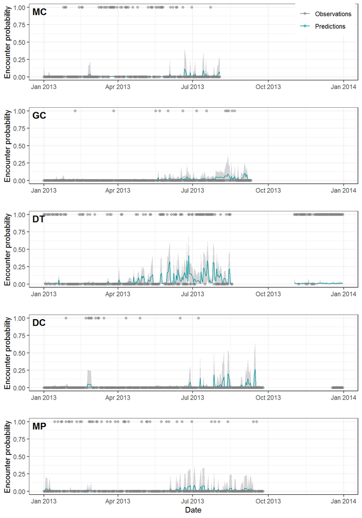

### 3.1.3 Joint prediction

**Predicted and observed encounter probabilities at passive acoustic monitoring sites using the joint model:**

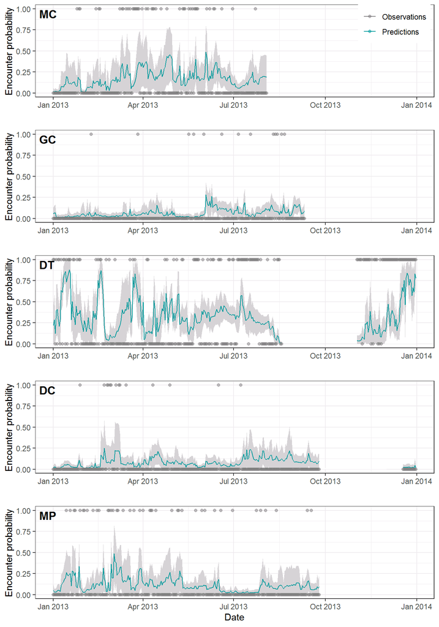

## 3.2 Spatial predictions

Models were evaluated for summer (July 2009) and winter(January 2009) across the entire Gulf of Mexico (US EEZ beyond the 200m contour).

Note: As an alternative to training joint models, an average surface was computed across the acoustic and visual-only predictions.

### 3.2.1 Summer 2009 predictions

**Summer 2009 predicted distribution and test sightings:**

[interactive chart not shown]

**Summer 2009 prediction uncertainty:**

[interactive chart not shown]

### 3.2.2 Winter 2009 predictions

**Winter 2009 predicted distribution:**

[interactive chart not shown]

**Winter 2009 prediction uncertainty:**

[interactive chart not shown]

### 3.3.3 How does hidden layer size change spatial predictions?

[interactive chart not shown]

# 4. Monthly model predictions

Spatial model predictions were generated using climatological means of oceanographic variables, averaged by month between 2003 and 2015.

[interactive chart not shown]

1. Frasier KE, Wiggins SM, Harris D, Marques TA, Thomas L, Hildebrand JA. Delphinid echolocation click detection probability on near-seafloor sensors. The Journal of the Acoustical Society of America. 2016;140: 1918–1930. doi:http://dx.doi.org/10.1121/1.4962279

2. Palka DL. Summer abundance estimates of cetaceans in us north atlantic navy operating areas. Northeast Fish Sci Cent Ref Doc. 2006; 06–03.

3. Hildebrand J, Baumann-Pickering S, Frasier K, Tricky J, Merkens K, Wiggins S, et al. Passive acoustic monitoring of beaked whale densities in the gulf of mexico during and after the deepwater horizon oil spill. Nature Scientific Reports. 2015;5: 16343.